**Instructor copy.** Executed notebook with all results shown, including the "after your attempt" cells. Projector/offline fallback; learners should use the notebook itself.

# f4c · The menu, its line and its prices (advanced steps 10–12)

**In plain words.** A computer that "calculates an equilibrium" chooses amounts of a list of candidate states so that every atom is kept and the energy is as low as possible. It also returns two extra numbers. In this notebook you find out that they are the chemical potentials, and that they draw a line under the states: a floor that holds for the list, but not for the states the list left out.

**Learning goals.** After this notebook you can

1. write the menu of step 10 as a linear programme and solve it;
2. turn the solver's two multipliers into the line $\mu_A+\Delta\mu\,x$ and check that it is a floor for the menu;
3. show with a gap curve that the same line is *not* a floor for the continuous curves, and how far to lower it so that it is;
4. (dive deeper) read off the range of $z$ over which the line stays put, and see a line that can rotate.

**What you need.** Steps 10–12 of the course, or at least their cards: the lever rule, reading a line, floor and ceiling, dual or shadow price, reduced cost. No derivatives are needed.

| Section | What | Track | Time |
| --- | --- | --- | --- |
| 1 | The menu by hand | main | 15 min |
| 2 | The menu as a linear programme | main | 15 min |
| 3 | The line and its prices | main | 15 min |
| 4 | The gap curve: a floor for the menu only | main | 15 min |
| 5 | Moving z: ranging | dive deeper | 10 min |
| 6 | A line that can rotate | dive deeper | 10 min |
| 7 | Exercises | both | 20 min |

**Coming from materials.** You have done every step of this by hand on steps 00–04: the lever rule, the chord rule, the tangent and its end heights. The new part is the computer's view of it, and the idea of a *floor*.

**Coming from operations research.** This is a two-row LP over candidate columns, its dual and complementary slackness. The new part is what each dual means physically, and that the column set is a sample of a continuum.

**How to work.** Run the cells from top to bottom. In each "Your turn" cell, replace `None` with your value and run it: `check` says whether you match, without showing the answer. Cells marked *After your attempt* hold worked solutions.

```python
# Setup: run this cell first. Locally it finds the course folder; in Colab it
# downloads the tested course release and the locked package versions.
# In Colab, the first run then restarts the session on purpose and Colab reports
# a crash: that is expected. Run this cell again, then the rest of the notebook.
RELEASE = "main"
import os, pathlib, subprocess, sys, time
ROOT = next((p for p in (pathlib.Path.cwd(), *pathlib.Path.cwd().parents)
             if (p / "pyproject.toml").is_file() and (p / "course").is_dir()), None)
if ROOT is None and "google.colab" in sys.modules:
    ROOT = pathlib.Path("/content/CalphadIntro")
    if not ROOT.is_dir():
        clone = ["git", "clone", "-q", "--depth", "1", "--branch", RELEASE,
                 "https://github.com/ukerzel/CalphadIntro.git", str(ROOT)]
        git = dict(os.environ, GIT_TERMINAL_PROMPT="0")
        if subprocess.run(clone, env=git, capture_output=True).returncode:
            raise SystemExit(f"Could not download course release {RELEASE}: check the internet "
                             "connection and run this cell again.")
    if not (ROOT / ".colab-ready").exists():
        if subprocess.run([sys.executable, "-m", "pip", "install", "-q", "-r",
                           str(ROOT / "notebooks" / "requirements-colab.txt")]).returncode:
            raise SystemExit("Installing the course packages failed; run this cell again.")
        (ROOT / ".colab-ready").touch()
        # Colab has already loaded its own numpy; a fresh session is needed to use the installed versions.
        print("Installed the course's package versions. Colab now restarts this session and"
              " reports a crash; that is expected. When it has reconnected, run this cell again"
              " (it will not install twice), then the rest of the notebook.", flush=True)
        time.sleep(3)
        os.kill(os.getpid(), 9)
if ROOT is None:
    raise SystemExit("Open this notebook from the course folder (poetry run jupyter lab) or in Colab.")
os.chdir(ROOT)
sys.path.insert(0, str(ROOT))
from notebooks.helpers import check, confirm, database, show_versions
show_versions(RELEASE)
```

```
Course release main · Python 3.12.14
  numpy       2.5.3
  scipy       1.18.1
  matplotlib  3.11.2
  xarray      2026.7.0
  pycalphad   0.11.2
```

```
True
```

## 0. Numbers you may change, and the tools

The cell below holds every number this notebook starts from. Leave them as they are for the first run: the "Your turn" checks expect these values. Later, change one number at a time and rerun everything below it.

- `T`: the temperature in K (the melting lens of step 03 part C at 1400 K);
- `z`: the overall B atom fraction of the sample;
- `MENU_X`: the compositions of the menu's dots, the same for both phase models.

```python
T = 1400.0                         # K
z = 0.40                           # overall B atom fraction of the sample
MENU_X = [0.1, 0.3, 0.5, 0.7, 0.9]  # the step 10 menu; z is not on it
```

Three libraries and one course module. `day3_core` is the small library that also produced every number on the advanced steps of the website, so your results here and the pages agree digit for digit. It contains the two phase models of the lens (`lens_models`), the menu solver and the pricing step; this notebook opens each of them up.

Colours follow the website: SOLID blue, LIQUID orange.

```python
import numpy as np
import matplotlib.pyplot as plt
from scipy.optimize import linprog
from course.self_study import day3_core as d

SOLID_C, LIQUID_C, LINE_C = "#2445c4", "#cf4418", "#8f6400"   # the website's colours
models = d.lens_models(T)          # {'SOLID': model, 'LIQUID': model}; each has .g(x)
```

## 1. The menu by hand (main track, 15 min)

A *state* is one phase model at one composition: a dot on the $g$–$x$ plot. The menu has five SOLID dots and five LIQUID dots. `models[p].g(x)` returns the molar Gibbs energy in J per mole of atoms.

```python
dots = []                                   # (phase, x, g) for every dot of the menu
for phase in ("SOLID", "LIQUID"):
    for x in MENU_X:
        dots.append((phase, x, float(models[phase].g(x))))
for phase, x, g in dots:
    print(f"{phase:6s} x = {x:.1f}   g = {g:10.2f} J/mol atoms")
```

```
SOLID  x = 0.1   g =  -16684.06 J/mol atoms
SOLID  x = 0.3   g =  -19810.64 J/mol atoms
SOLID  x = 0.5   g =  -20568.44 J/mol atoms
SOLID  x = 0.7   g =  -19410.64 J/mol atoms
SOLID  x = 0.9   g =  -15884.06 J/mol atoms
LIQUID x = 0.1   g =  -18444.06 J/mol atoms
LIQUID x = 0.3   g =  -20290.64 J/mol atoms
LIQUID x = 0.5   g =  -19768.44 J/mol atoms
LIQUID x = 0.7   g =  -17330.64 J/mol atoms
LIQUID x = 0.9   g =  -12524.06 J/mol atoms
```

A sample at $z=0.40$ can be made from one dot left of 0.40 and one dot right of it. The lever rule fixes the amounts:

$$f_{\text{right}}=\frac{z-x_{\text{left}}}{x_{\text{right}}-x_{\text{left}}},\qquad f_{\text{left}}=1-f_{\text{right}},$$

and the mixture's energy is $f_{\text{left}}\,g_{\text{left}}+f_{\text{right}}\,g_{\text{right}}$ (the chord rule).

### Your turn: one mixture

Find the energy of the mixture of LIQUID at 0.3 and SOLID at 0.5 that makes $z=0.40$. Use the printed energies.

```python
g_pair = None   # J/mol atoms
check(g_pair, "f4c_g_menu_pair")
```

```
f4c_g_menu_pair: not attempted yet. Replace None with your value and run the cell again.
```

**Predict first.** Of all pairs that bracket 0.40, which do you expect to be the cheapest? The next cell tries every pair. It is a plain double loop: for every left dot and every right dot it applies the lever rule.

```python
best = None
for pl, xl, gl in dots:
    for pr, xr, gr in dots:
        if xl < z < xr:
            f_right = (z - xl) / (xr - xl)
            G = (1 - f_right) * gl + f_right * gr
            if best is None or G < best[0]:
                best = (G, pl, xl, pr, xr, f_right)
print("cheapest pair: %s %.1f and %s %.1f, amounts %.3f and %.3f, G = %.2f" % (best[1], best[2], best[3], best[4], 1 - best[5], best[5], best[0]))
```

```
cheapest pair: LIQUID 0.3 and SOLID 0.5, amounts 0.500 and 0.500, G = -20429.54
```

## 2. The menu as a linear programme (main track, 15 min)

The loop above tried pairs. A computer states the problem once and lets a solver search:

- **variables:** the amounts $f_j\ge0$ of every dot $j$;
- **objective:** the total energy $\sum_j f_j g_j$, as small as possible;
- **constraints:** $\sum_j f_j=1$ (all atoms are somewhere) and $\sum_j f_j x_j=z$ (all B atoms are somewhere).

In `linprog` this is `c` (the energies), `A_eq` (two rows: ones and the compositions) and `b_eq` (1 and $z$). `method="highs-ds"` asks for the dual simplex method, which returns a *basic* answer: at most as many dots with a non-zero amount as there are constraint rows, here two.

```python
c = np.array([g for _, _, g in dots])                      # energy of each dot
A_eq = np.array([[1.0] * len(dots), [x for _, x, _ in dots]])  # row 1: amounts; row 2: B atoms
b_eq = np.array([1.0, z])
result = linprog(c, A_eq=A_eq, b_eq=b_eq, bounds=(0, None), method="highs-ds")
f = result.x                                               # amounts, mol atoms per mol sample
G_up = result.fun                                          # the cheapest energy of the menu
print(result.message)
```

```
Optimization terminated successfully. (HiGHS Status 7: Optimal)
```

```python
for (phase, x, g), amount in zip(dots, f):
    if amount > 1e-12:
        print(f"uses {phase} at x = {x:.1f}: f = {amount:.4f}")
print(f"G_up = {G_up:.2f} J/mol atoms   (the best mixture of the menu: a ceiling)")
```

```
uses SOLID at x = 0.5: f = 0.5000
uses LIQUID at x = 0.3: f = 0.5000
G_up = -20429.54 J/mol atoms   (the best mixture of the menu: a ceiling)
```

Two checks every LP answer must pass, whoever solved it: the amounts keep the atoms, and no amount is negative. The messages say in words what went wrong if a check fails.

```python
assert abs(f.sum() - 1) < 1e-9, f"amounts sum to {f.sum():.6f}, not 1"
assert abs(f @ A_eq[1] - z) < 1e-9, f"B atoms sum to {f @ A_eq[1]:.6f}, not z = {z}"
assert f.min() > -1e-12, f"a negative amount: {f.min():.3g}"
if (T, z, MENU_X) == (1400.0, 0.40, [0.1, 0.3, 0.5, 0.7, 0.9]):   # only the page's own numbers have a lesson value to compare with
    confirm(G_up, -20429.542431, "The menu's cheapest mixture", tol=1e-5)
else:
    print("You changed the numbers in section 0: no lesson value to compare with.")
```

```
✓ The menu's cheapest mixture reproduces the lesson value.
```

## 3. The line and its prices (main track, 15 min)

Besides the amounts, the solver returns one *multiplier* per constraint row: how much the optimal energy changes when that row's right-hand side changes a little, as long as the same dots stay in use (section 6 shows a case where they are not unique). `result.eqlin.marginals` holds them. For our rows $(1, z)$ they are exactly the intercept and the slope of a straight line:

- $\mu_A$, the line's height at $x=0$ (from the "amounts" row);
- $\Delta\mu=\mu_B-\mu_A$, its slope (from the "B atoms" row).

The sign convention matters: SciPy reports $\partial G_{\text{up}}/\partial b$, which is what we want here (some other solvers report the negative).

```python
mu_A, d_mu = result.eqlin.marginals   # d(G_up)/d(1) and d(G_up)/dz: the line's intercept and slope
mu_B = mu_A + d_mu                    # the line's height at x = 1
print(f"mu_A = {mu_A:.1f}   d_mu = {d_mu:.1f}   mu_B = {mu_B:.1f}   (J/mol)")
```

```
mu_A = -19873.9   d_mu = -1389.0   mu_B = -21262.9   (J/mol)
```

**Check 1: the line passes through the used dots**, so its height at $z$ is the ceiling. This is strong duality for the menu: the best floor equals the best mixture.

```python
line_at_z = mu_A + d_mu * z
assert abs(line_at_z - G_up) < 1e-8, f"line at z is {line_at_z:.4f}, the ceiling {G_up:.4f}"
print(f"line at z = {line_at_z:.2f} = ceiling {G_up:.2f}")
```

```
line at z = -20429.54 = ceiling -20429.54
```

**Check 2: no dot lies below the line.** Subtract the line's height from every dot's energy. This difference is the dot's *gap* (its reduced cost). Used dots have gap zero; every other dot must have gap zero or more, or the line would not be a floor for the menu.

```python
gaps = [g - (mu_A + d_mu * x) for _, x, g in dots]
for (phase, x, _), gap in zip(dots, gaps):
    print(f"{phase:6s} x = {x:.1f}: gap = {gap:8.1f}")
assert min(gaps) > -1e-8, f"a dot lies {min(gaps):.3g} J/mol below the line"
```

```
SOLID  x = 0.1: gap =   3328.8
SOLID  x = 0.3: gap =    480.0
SOLID  x = 0.5: gap =      0.0
SOLID  x = 0.7: gap =   1435.6
SOLID  x = 0.9: gap =   5240.0
LIQUID x = 0.1: gap =   1568.8
LIQUID x = 0.3: gap =      0.0
LIQUID x = 0.5: gap =    800.0
LIQUID x = 0.7: gap =   3515.6
LIQUID x = 0.9: gap =   8600.0
```

**Check 3: the slope is the price of B.** Move $z$ a little, solve again and compare the change of the cheapest energy with $\Delta\mu\times$ the change.

```python
dz = 0.001
moved = linprog(c, A_eq=A_eq, b_eq=[1.0, z + dz], bounds=(0, None), method="highs-ds")
print(f"energy change {moved.fun - G_up:.4f}  against  d_mu * dz = {d_mu * dz:.4f}")
assert abs((moved.fun - G_up) - d_mu * dz) < 1e-6, "the slope is not the price of B"
```

```
energy change -1.3890  against  d_mu * dz = -1.3890
```

### Your turn: read the line

1. What is $\mu_B$, the line's height at $x=1$?
2. Nudge $z$ by $+0.01$. By how much does the cheapest energy change?

```python
mu_B_answer = None   # J/mol
nudge = None         # J/mol atoms, with its sign
check(mu_B_answer, "f4c_mu_b_menu")
check(nudge, "f4c_nudge")
```

```
f4c_mu_b_menu: not attempted yet. Replace None with your value and run the cell again.
f4c_nudge: not attempted yet. Replace None with your value and run the cell again.
```

## 4. The gap curve: a floor for the menu only (main track, 15 min)

The line lies under every dot of the menu. Does it lie under the whole curves? Draw the gap for every composition of each phase model: $g(x)$ minus the line.

**Predict first:** will the curves stay at or above zero between the dots?

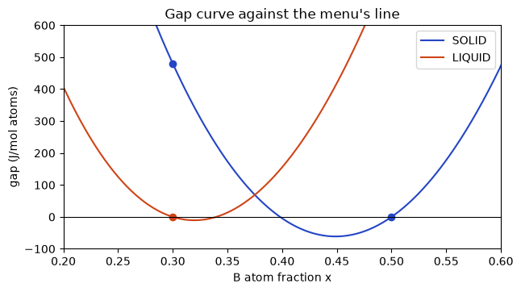

```python
xs = np.linspace(0.001, 0.999, 999)
fig, ax = plt.subplots(figsize=(7, 3.6))
for phase, colour in (("SOLID", SOLID_C), ("LIQUID", LIQUID_C)):
    ax.plot(xs, models[phase].g(xs) - (mu_A + d_mu * xs), color=colour, label=phase)
    ax.plot(MENU_X, [g for p, _, g in dots if p == phase] - (mu_A + d_mu * np.array(MENU_X)), "o", color=colour)
ax.axhline(0, color="black", lw=0.8)
ax.set(xlim=(0.2, 0.6), ylim=(-100, 600), xlabel="B atom fraction x", ylabel="gap (J/mol atoms)", title="Gap curve against the menu's line")
ax.legend(); plt.show()
```

Between the dots the SOLID curve dips below zero. The menu's line is a floor for mixtures of the menu, not for every state. How deep does the curve go? For these ideal phase models the deepest point of the gap curve has a formula; `d.deepest` applies it to both phase models and returns the deepest dip overall and each phase model's own dip.

```python
deepest, dips = d.deepest(models, mu_A, d_mu)
for phase, dip in dips.items():
    print(f"{phase:6s}: deepest point at x = {dip.x:.4f}, gap {dip.depth:.2f} J/mol atoms")
assert deepest.depth < 0, "expected the curves to dip below the menu's line"
```

```
SOLID : deepest point at x = 0.4489, gap -61.18 J/mol atoms
LIQUID: deepest point at x = 0.3197, gap -10.53 J/mol atoms
```

Lower the line, keeping its slope, by the deepest dip. Now no state of either phase model lies below it: check it on a fine grid. (A grid can only test this; the formula for the deepest point is what guarantees it.)

```python
lowered = mu_A + deepest.depth            # the same slope, moved down by the deepest dip
for phase in ("SOLID", "LIQUID"):
    lowest = (models[phase].g(xs) - (lowered + d_mu * xs)).min()
    assert lowest > -1e-6, f"{phase} still dips {lowest:.3g} below the lowered line"
G_low = lowered + d_mu * z                # a floor for every state: step 14's floor
print(f"floor {G_low:.2f} <= truth <= ceiling {G_up:.2f}; remaining uncertainty {G_up - G_low:.1f} J/mol atoms")
```

```
floor -20490.72 <= truth <= ceiling -20429.54; remaining uncertainty 61.2 J/mol atoms
```

### Your turn: read the gap curve

1. What is the gap of the SOLID dot at $x=0.3$?
2. How deep is the deepest dip of the whole curve (a negative number)?

```python
gap_solid_03 = None   # J/mol atoms
deepest_dip = None    # J/mol atoms, negative
check(gap_solid_03, "f4c_gap_solid_03")
check(deepest_dip, "f4c_deepest_dip")
```

```
f4c_gap_solid_03: not attempted yet. Replace None with your value and run the cell again.
f4c_deepest_dip: not attempted yet. Replace None with your value and run the cell again.
```

## 5. Moving z: ranging (dive deeper, 10 min)

Keep the menu and move $z$. Inside the range where the same two dots stay in use, the line does not move: the prices stay the same across the two-phase region. Outside it the used dots, and the line, change.

```python
for zz in (0.25, 0.30, 0.35, 0.40, 0.45, 0.50, 0.55):
    r = linprog(c, A_eq=A_eq, b_eq=[1.0, zz], bounds=(0, None), method="highs-ds")
    used = [f"{p} {x:.1f}" for (p, x, _), a in zip(dots, r.x) if a > 1e-12]
    print(f"z = {zz:.2f}: uses {', '.join(used):24s} d_mu = {r.eqlin.marginals[1]:9.1f}")
```

```
z = 0.25: uses LIQUID 0.1, LIQUID 0.3   d_mu =   -9232.9
z = 0.30: uses LIQUID 0.3               d_mu =   -9232.9
z = 0.35: uses SOLID 0.5, LIQUID 0.3    d_mu =   -1389.0
z = 0.40: uses SOLID 0.5, LIQUID 0.3    d_mu =   -1389.0
z = 0.45: uses SOLID 0.5, LIQUID 0.3    d_mu =   -1389.0
z = 0.50: uses SOLID 0.5                d_mu =   -1389.0
```

```
z = 0.55: uses SOLID 0.5, SOLID 0.7     d_mu =    5789.0
```

For $0.3<z<0.5$ the line is the same. At exactly 0.3 or 0.5 the sample sits on a used dot and the solver may return a different line (section 6). The true two-phase region of the continuous curves, 0.312 to 0.441, is narrower: the coarse menu blurs it.

## 6. A line that can rotate (dive deeper, 10 min)

Step 03 part D's coarse grid has dots at 0.2, 0.4, 0.6 and 0.8, so the sample at 0.40 sits exactly on a dot, and the solver uses that one SOLID dot alone. Which line do the multipliers give now? Ask two solver methods.

```python
coarse = d.menu_states(models, [0.2, 0.4, 0.6, 0.8])
c2 = np.array([s.g for s in coarse])
A2 = np.array([[1.0] * len(coarse), [s.x for s in coarse]])
for method in ("highs-ds", "highs-ipm"):
    r = linprog(c2, A_eq=A2, b_eq=[1.0, z], bounds=(0, None), method=method)
    print(f"{method:9s}: G = {r.fun:.4f}   mu_A = {r.eqlin.marginals[0]:9.2f}   d_mu = {r.eqlin.marginals[1]:9.2f}")
```

```
highs-ds : G = -20434.0577   mu_A = -20434.06   d_mu =     -0.00
highs-ipm: G = -20434.0577   mu_A = -19055.61   d_mu =  -3446.12
```

The energy is the same; the line may not be. Any line through the used dot that stays under its neighbours is optimal: its slope can be anything between the slopes of the chords to the neighbouring dots on the lower envelope. The next cell computes that range from the dots.

```python
on_grid = [s for s in coarse if abs(s.x - z) < 1e-12]                       # dots exactly at z
if on_grid:
    used = min(on_grid, key=lambda s: s.g)                                  # the cheaper dot at z
    left = max((s.g - used.g) / (s.x - used.x) for s in coarse if s.x < z)  # steepest chord to the left
    right = min((s.g - used.g) / (s.x - used.x) for s in coarse if s.x > z) # shallowest chord to the right
    print(f"every slope between {left:.1f} and {right:.1f} gives an optimal line")
else:
    print(f"z = {z} is not on the coarse grid: the line cannot rotate there")
```

```
every slope between -3446.1 and 1000.0 gives an optimal line
```

Different solvers may pick different members of that range; both are right. The card "What if the answer is not unique?" separates this case (a line that can rotate) from the other one (several optimal amounts).

## 7. Exercises

**Materials flavour: run, change one number, explain.**

- Set `z = 0.45` in section 0 and rerun. Which dots are used, and does the line change? Explain with the lever rule.
- Add 0.44 to `MENU_X` and rerun. By how much does the ceiling drop, and why does one extra dot near the true solid composition help so much?

**Optimisation flavour: complete a function, then one deeper exercise.**

Complete `line_from_basis`: given the two used dots (as `(x, g)` pairs), return `(mu_A, d_mu)` by making the line pass through both. Do not call `linprog`.

```python
def line_from_basis(dot1, dot2):
    """The line through two used dots: two equations, two unknowns."""
    return None   # replace with (mu_A, d_mu)

guess = line_from_basis((0.3, float(models["LIQUID"].g(0.3))), (0.5, float(models["SOLID"].g(0.5))))
check(None if guess is None else guess[1], "f4c_line_from_basis")
```

```
f4c_line_from_basis: not attempted yet. Replace None with your value and run the cell again.
```

```python
#@title After your attempt: a solution of line_from_basis
def line_from_basis_solution(dot1, dot2):
    (x1, g1), (x2, g2) = dot1, dot2
    slope = (g2 - g1) / (x2 - x1)          # the line rises by g2 - g1 over x2 - x1
    return g1 - slope * x1, slope          # the intercept puts the line through dot1

print(line_from_basis_solution((0.3, float(models["LIQUID"].g(0.3))), (0.5, float(models["SOLID"].g(0.5)))))
```

```
(-19873.947649216047, -1388.986953311778)
```

**Deeper exercise (operations research).** Write the dual LP explicitly: maximise $\mu_A+\Delta\mu\,z$ subject to $\mu_A+\Delta\mu\,x_j\le g_j$ for every dot, with both variables free. Solve it with `linprog` (which minimises, so negate the objective) and compare with the marginals. Then test the affine shift: add $a+bx$ to every dot's energy, solve the menu again, and show that the amounts stay the same while $\mu_A$ moves by $a$ and $\Delta\mu$ by $b$.

```python
#@title After your attempt: the dual LP and the affine shift
dual = linprog([-1.0, -z], A_ub=np.column_stack([np.ones(len(dots)), [x for _, x, _ in dots]]), b_ub=c,
               bounds=[(None, None), (None, None)], method="highs-ds")
print(f"dual: mu_A = {dual.x[0]:.4f}, d_mu = {dual.x[1]:.4f}, value {-dual.fun:.4f}")
assert np.allclose(dual.x, [mu_A, d_mu]) and abs(-dual.fun - G_up) < 1e-8, "dual and primal disagree"
a, b = 1000.0, -500.0
shifted = linprog(c + a + b * A_eq[1], A_eq=A_eq, b_eq=b_eq, bounds=(0, None), method="highs-ds")
print("same amounts:", np.allclose(shifted.x, f), "  mu_A moved by", round(shifted.eqlin.marginals[0] - mu_A, 6),
      "  d_mu moved by", round(shifted.eqlin.marginals[1] - d_mu, 6))
```

```
dual: mu_A = -19873.9476, d_mu = -1388.9870, value -20429.5424
same amounts: True   mu_A moved by 1000.0   d_mu moved by -500.0
```

## Recap

- The menu is a two-row linear programme: amounts are the variables, the atom balances the constraints, the energy the objective.
- Its two multipliers are the line $\mu_A+\Delta\mu\,x$: the chemical potential of A and the exchange price $\mu_B-\mu_A$.
- The line is a floor for the menu (every dot on or above it) and meets the ceiling there. It is not a floor for the continuous curves: they dip 61.2 J/mol atoms below it near SOLID 0.4489.
- Lowered by the deepest dip, the line is a floor for every state: step 14.

**Next:** notebook f4d adds the missing states one by one (column generation). On the website: steps 10 (the menu), 11 (the line) and 12 (the gap curve). Cards: the lever rule, reading a line, floor and ceiling, dual or shadow price, reduced cost.

**If a cell fails:** rerun the setup cell first; then check that section 0 still has its original numbers.